# **CMU 16825 Learning for 3D Vision – Assignment 3 Submission**

## **Patrick Chen** *(Andrew ID: bochunc)*

### **Task 0: Transmittance Calculation**

### **Task 1: Differentiable Volume Rendering**

🔹**Familiarize yourself with the code structure**  
🔹**Outline of tasks**  
🔹**Ray sampling**  
🔹**Point sampling**  
🔹**Volume rendering**

### **Task 2: Optimizing a basic implicit volume**

🔹**Random ray sampling**  
🔹**Loss and training**  
🔹**Visualization**

### **Task 3: Optimizing a Neural Radiance Field (NeRF) (20 points)**

🔹**Visualization**

### **Task 4: NeRF Extras (CHOOSE ONE! More than one is extra credit)**

🔹**View Dependence**  
🔹**Coarse/Fine Sampling**

### **Task 5: Sphere Tracing (10 points)**

### **Task 6: Optimizing a Neural SDF (15 points)**

### **Task 7: VolSDF (15 points)**

### **Task 8: Neural Surface Extras (CHOOSE ONE! More than one is extra credit)**

🔹**Render a Large Scene with Sphere Tracing**  
🔹**Fewer Training Views**  
🔹**Alternate SDF to Density Conversions**

## Task 0: Transmittance Calculation (10 points)

The following shows the answer of the transmittance:

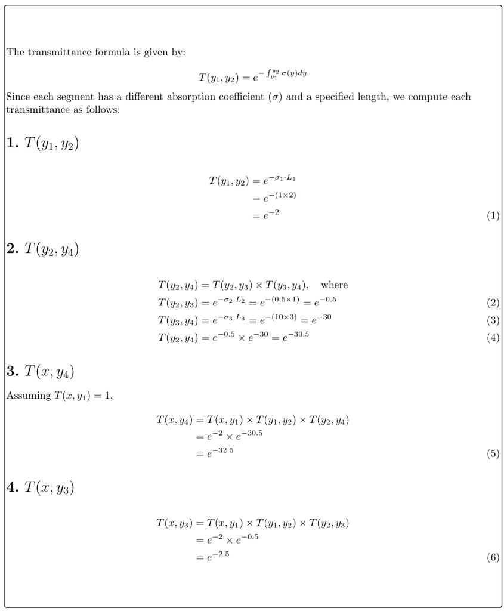

## Task 1.3: Ray sampling (5 points)

The following shows the rendered xy_grid and rays:

xy_grid

rays

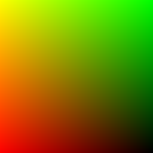

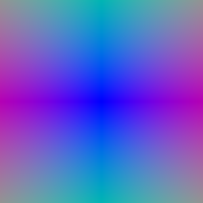

## Task 1.4: Point sampling (5 points)

The following shows the rendered sample points.

visualization of sample points

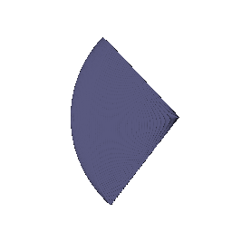

## Task 1.5: Volume rendering (20 points)

The following shows the rendered feature in GIF and depth image.

visualization of feature

visualization of depth

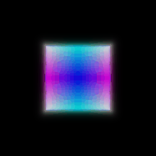

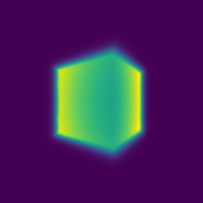

## Task 2.1: Random ray sampling (5 points)

The get_random_pixels_from_image() method is implemented in ray_utils.py.

`xy_grid = get_random_pixels_from_image(cfg.training.batch_size, image_size, camera) # TODO: implement in ray_utils.py`

## Task 2.2: Loss and training (5 points)

The loss has been replaced with: `loss = F.mse_loss(out['feature'], rgb_gt)`

And, the center of the box and the side lengths of the box after training are as the following (rounded to the nearest 1/100 decimal place):

Original standard output:

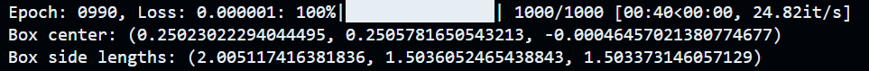

## Task 2.3: Visualization

The following shows the TA's volume gif and my optimized volume gif.

TA's Volume

My Optimzed Volume

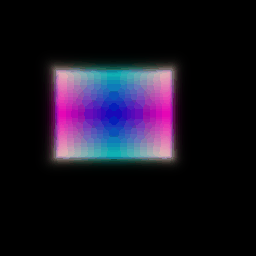

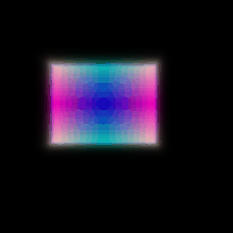

## Task 3: Optimizing a Neural Radiance Field (NeRF) (20 points)

The following shows the TA's provided result and my optmized result. My optimized result is generated by setting use_views=False, n_harmonic_functions_xyz=10, n_harmonic_functions_dir=2, n_hidden_neurons_xyz=256, n_hidden_neurons_dir=128, and n_layers_xyz=8 in ./configs/nerf_lego.yaml. The architecture is refering to the Fig.7 in the original NeRF paper: NeRF: Representing Scenes as Neural Radiance Fields for View Synthesis, with the modification that skip connection happens at layer 6 instead of layer 4 for improving sharpness. Besides, it uses ReLU to map the first network output to density and use the Sigmoid activation to map the remaining raw network outputs to color (color_layer) as guided in the README from TA. The Positional Encoding, HarmonicEmbedding, of the input to the network is used for higher quality.

TA's Result

My Optimzed Result

[figure not shown]

[figure not shown]

## Task 4.1: View Dependence (10 points)

The following shows the result of nerf_lego.yaml without and with view dependence:

1. Without view dependence, the Lego model appears flat and uniformly lit, meaning the shading remains constant regardless of the viewing direction.
2. With view dependence, subtle changes in shading and reflections appear, but the difference is not highly pronounced since Lego bricks are mostly diffuse surfaces with minimal specular reflection.

logo without view dependence

logo with view dependence

[figure not shown]

[figure not shown]

The following shows the result of nerf_materials.yaml without and with view dependence:

1. Without view dependence, the materials look dull and lack proper specular highlights, making them appear more like matte surfaces.
2. With view dependence, the materials exhibit shiny reflections and dynamic highlights, which change with the viewpoint, making the metallic and plastic surfaces appear more realistic.

materials without view dependence

materials with view dependence

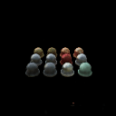

[figure not shown]

The following shows the result of nerf_materials_highres.yaml without and with view dependence:

1. Without view dependence, the high-resolution material samples look blurry and less defined, and the reflection looks weaker and more diffuse, not showing strong specular highlights, as the model fails to capture fine specular variations.
2. With view dependence, the highlights become crisper and more natural, showing stronger and more realistic reflections and specular highlights that looks closer to real-world shiny surfaces as there are more variation that changes based on the camera's viewpoint.

materials_highres without view dependence

materials_highres with view dependence

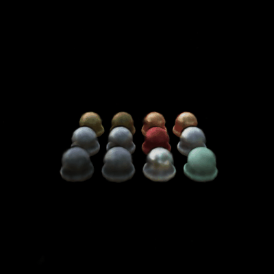

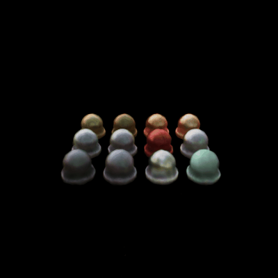

### Trade-off of View Dependence

Introducing view dependence in NeRF improves realism by accurately modeling specular highlights and reflective effects, making objects with shiny surfaces appear more natural. However, this comes at the cost of higher model complexity, longer training times, and increased risk of overfitting to specific lighting conditions from the training dataset. While it significantly benefits reflective surfaces, its impact on diffuse objects is minimal, meaning that for certain scenes (like the Lego scene), the added computational cost may not be justified. To get the best results, the model should be designed carefully so it doesn't just memorize the training images.

## Task 4.2: Coarse/Fine Sampling (10 points)

The following shows the result of nerf_materials_highres.yaml with stratified sampling at epoch 260 and coarse-fine sampling at epoch 200:

materials_highres with stratified sampling

materials_highres with coarse-fine sampling

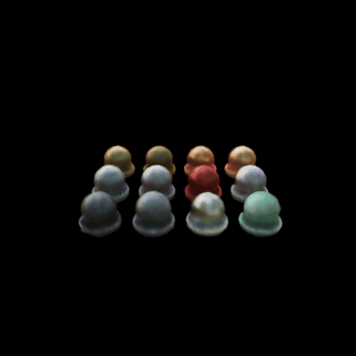

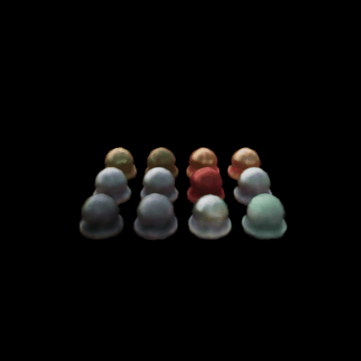

### Trade-Off Discussion

#### Speed vs. Sample Efficiency:

1. Stratified sampling has faster iteration speed per second (19.45it/s) since it uniformly samples points along the rays.
2. Coarse-fine sampling spends more computation per step (12.06it/s), but its adaptive sampling strategy allows it to converge much faster in terms of epochs.

#### Rendering Quality:

1. Coarse-fine sampling produces better-defined shapes and reflections because the fine network focuses more on key areas where scene complexity is high.
2. Stratified sampling struggles with sharp and fine geometric details, requiring more epochs to refine the scene.

#### Convergence Time:

1. The coarse-fine model achieves similar rendering quality at epoch 200, whereas stratified sampling needs 260 epochs for comparable results.
2. This suggests that while stratified sampling is computationally cheaper per step, it requires significantly more training epochs to match the fine details achieved by coarse-fine sampling.

## Task 5: Sphere Tracing (10 points)

The following shows the TA's result and my result of sphere tracing function in renderer.py on rendering a simple torus:

TA's Result

My Result

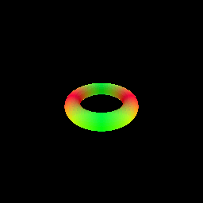

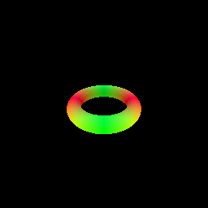

In this implementation, I used the sphere tracing algorithm to render a torus by iteratively marching along ray directions based on the Signed Distance Function (SDF). The algorithm initializes points at ray origins and iteratively updates their positions by moving them along the ray direction by a step size equal to the SDF value at each point. If the SDF value is below a small threshold (self.epsilon=1e-7), the ray is considered to have converged, and its position is recorded. A boolean mask is maintained to track which rays intersected the surface. The algorithm stops either when all rays have converged or when the maximum number of iterations is reached. This adaptive step size ensures efficient convergence while preventing unnecessary computations. The rendered torus closely matches the TA's result, confirming the correctness of the implementation and demonstrating an effective approach to implicit surface rendering.

## Task 6: Optimizing a Neural SDF (15 points)

The following shows the TA's input and result, and my input and result of the point cloud data and the predicted SDF:

TA's Input

My Input

TA's Result

My Result

[figure not shown]

[figure not shown]

[figure not shown]

[figure not shown]